# Dimension Reduction

Mr. Sachin B.

## 1. Dimension Reduction

- Dimension Reduction is process of finding subsets of variables in datasets that contain their essences.
- As data scientists, we’d like to find a smaller set of multivariate variables that are uncorrelated AND explain as much variance (or variability) of the data as possible.
  - This is a statistical approach.
- In other words, we’d like to find the best matrix created with fewer variables (that is, a lower rank matrix) that explains the original data.
  - This is related to data compression.
- Two related solutions to these problems are
  1. **PCA** which stands for Principal Component Analysis and
  2. **SVD**, Singular Value Decomposition.

### 1.1. **SVD**, Singular Value Decomposition

#### $X=UDV^t$

- This latter simply means that we express a matrix $X$ of observations (rows) and variables (columns) as the product of 3 other matrices.
  - This last term ($V^t$) represents the transpose of the matrix $V$.
- Here,
  - $U$ and $V$ each have orthogonal (uncorrelated) columns.
  - $D$ is a diagonal matrix, by which we mean that all of its entries not on the diagonal are 0.
1. $U$’s columns are the left singular vectors of $X$ and
2. $V$’s columns are the right singular vectors of $X$.
3. The diagonal entries of $D$ are the singular values of $X$.

#### 1.1.1. Original Matrix

```r
matx <- matrix(c(1,2,2,5,3,7), nrow = 2)
matx
```

```
##      [,1] [,2] [,3]
## [1,]    1    2    3
## [2,]    2    5    7
```

#### 1.1.2. svd()

```r
svd_res <- svd(matx)
svd_res
```

```
## $d
## [1] 9.5899624 0.1806108
##
## $u
##            [,1]       [,2]
## [1,] -0.3897782 -0.9209087
## [2,] -0.9209087  0.3897782
##
## $v
##            [,1]       [,2]
## [1,] -0.2327012 -0.7826345
## [2,] -0.5614308  0.5928424
## [3,] -0.7941320 -0.1897921
```

##### Explanation:

- We see that the function returns 3 components,
  1. `d` which holds 2 diagonal elements,
  2. `u`, a 2 by 2 matrix, and
  3. `v`, a 3 by 2 matrix.

#### 1.1.3.Recover Original Matrix from SVD Matrices

Syntax: $X=UDV^t$

```r
matx_recovered <- svd_res$u %*% diag(svd_res$d) %*% t(svd_res$v)

matx_recovered
```

```
##      [,1] [,2] [,3]
## [1,]    1    2    3
## [2,]    2    5    7
```

```r
# Cross Check
all.equal(matx, matx_recovered)
```

```
## [1] TRUE
```

### 1.2 **PCA**, Principal Component Analysis

- Principal Component Analysis, “a simple, non-parametric method for extracting relevant information from confusing data sets.”
- The paper by Jonathon Shlens of Google Research is called, A Tutorial on Principal Component Analysis.
  - http://arxiv.org/pdf/1404.1100.pdf.
- Basically, **PCA is a method to reduce a high-dimensional data set to its essential elements (not lose information) and explain the variability in the data.**

#### 1.2.1 SVD and PCA are closely related

**Demonstration**:

1. First we have to scale matx, (our simple example data matrix.)
- This means that we subtract the column mean from every element and divide the result by the column standard deviation.
- `scale`, that does this for us.

#### 1.2.2 svd() on scale of matx

```r
svd(scale(matx))
```

```
## $d
## [1] 1.732051 0.000000
##
## $u
##            [,1]      [,2]
## [1,] -0.7071068 0.7071068
## [2,]  0.7071068 0.7071068
##
## $v
##           [,1]       [,2]
## [1,] 0.5773503 -0.5773503
## [2,] 0.5773503  0.7886751
## [3,] 0.5773503 -0.2113249
```

2. Now run the R program prcomp on scale(mat).
- This will give you the principal components of matx.

#### 1.2.3 prcomp() on scale of matx

```r
prcomp(scale(matx))
```

```
## Standard deviations (1, .., p=2):
## [1] 1.732051 0.000000
##
## Rotation (n x k) = (3 x 2):
##            PC1        PC2
## [1,] 0.5773503 -0.5773503
## [2,] 0.5773503  0.7886751
## [3,] 0.5773503 -0.2113249
```

#### 1.2.4 Explanation

- Notice that the principal components of the scaled matrix (**PC1 & PC2**), shown in the Rotation component **of the prcomp output**,
- **ARE the**
- **columns of V, the right singular values in svd output**.
- Thus, **PCA of a scaled matrix yields the V matrix (right singular vectors of svd) of the same scaled matrix**.

## 2. Case Study: Single Pattern Finding using PCA & SVD

### 2.1. Dataset without Any Pattern (Random Dataset)

```r
set.seed(12345)
dataMat <- matrix(rnorm(400), nrow = 40)
head(dataMat)
```

```
##            [,1]       [,2]       [,3]       [,4]       [,5]       [,6]
## [1,]  0.5855288  1.1285108  0.6453831  1.5448636 -0.4876385 -1.4361457
## [2,]  0.7094660 -2.3803581  1.0431436  1.3214520  0.3031512 -0.6292596
## [3,] -0.1093033 -1.0602656 -0.3043691  0.3221516 -0.2419740  0.2435218
## [4,] -0.4534972  0.9371405  2.4771109  1.5309551 -0.4817336  1.0583622
## [5,]  0.6058875  0.8544517  0.9712207 -0.4212397 -0.9918029  0.8313488
## [6,] -1.8179560  1.4607294  1.8670992 -1.1588210 -0.2806491  0.1052118
##            [,7]       [,8]       [,9]       [,10]
## [1,] -0.7000758 -1.5138641  0.3803157 -0.37582344
## [2,] -0.5674016  0.1642810  0.6051368 -1.81283376
## [3,] -0.2613939 -0.8708652  1.0196741  0.28860021
## [4,] -1.0638850  1.5933290  0.4749430 -0.18962258
## [5,] -0.1063687  0.6465975 -2.1859464  0.01786021
## [6,]  0.7711037  0.3573697  0.9331922  0.65043024
```

##### Explanation

- This is dataMat, a matrix of 400 random normal numbers (mean 0 and standard deviation 1).
- dataMat has 10 columns (and hence 40 rows) of random numbers.

#### 2.1.1 Image of Random Numbers (dataMat)

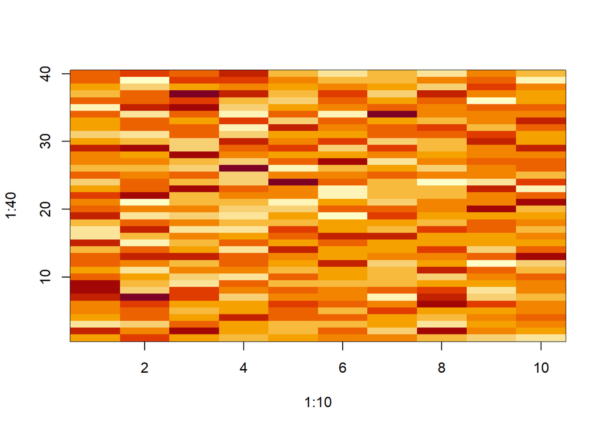

```r
image(1:10,1:40,t(dataMat)[,nrow(dataMat):1])
```

##### Explanation:

- The image here looks pretty random.

#### 2.1.2 heatmap()

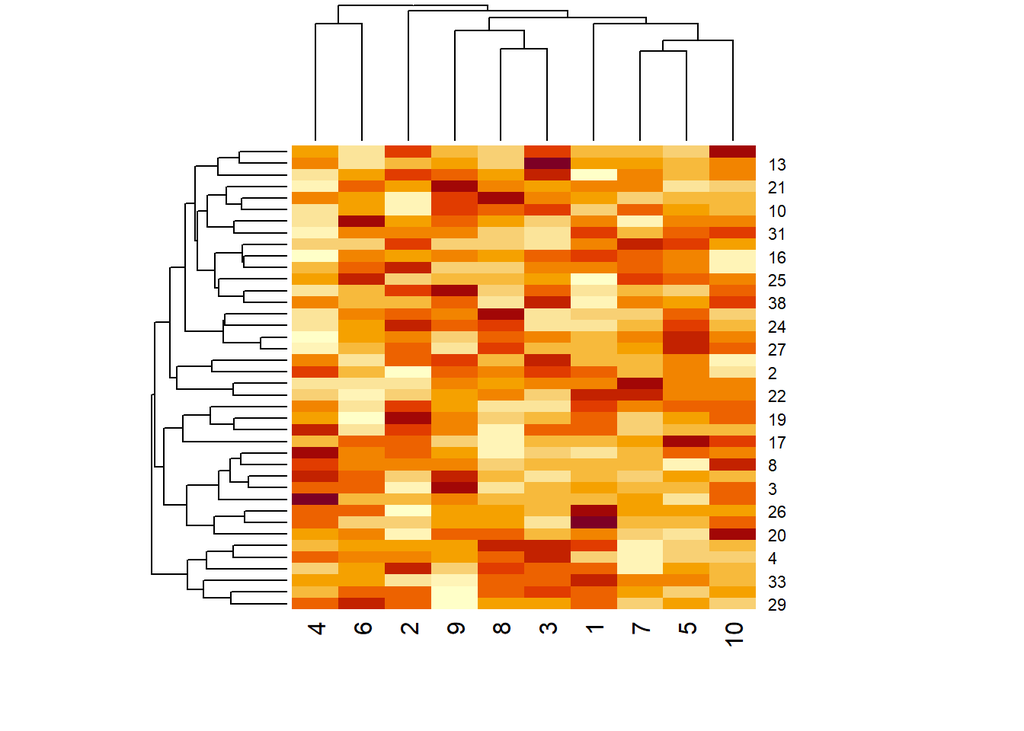

```r
heatmap(dataMat)
```

##### Explanation:

- We can see that even with the clustering that heatmap provides, permuting the rows (observations) and columns (variables) independently,
- the data still looks random.

### 2.2. Dataset with Pattern

```r
set.seed(678910)
for(i in 1:40){
  # flip a coin
  coinFlip <- rbinom(1,size=1,prob=0.5)
  # if coin is heads add a common pattern to that row
  if(coinFlip){
    dataMat[i,] <- dataMat[i,] + rep(c(0,3),each=5)
  }
}
```

##### Explanation:

- So whether or not a row gets modified by a pattern is determined by a coin flip.
- So in rows affected by the coin flip, the 5 left columns will still have a mean of 0 but the right 5 columns will have a mean closer to 3.

#### 2.2.1 Image with Pattern Added

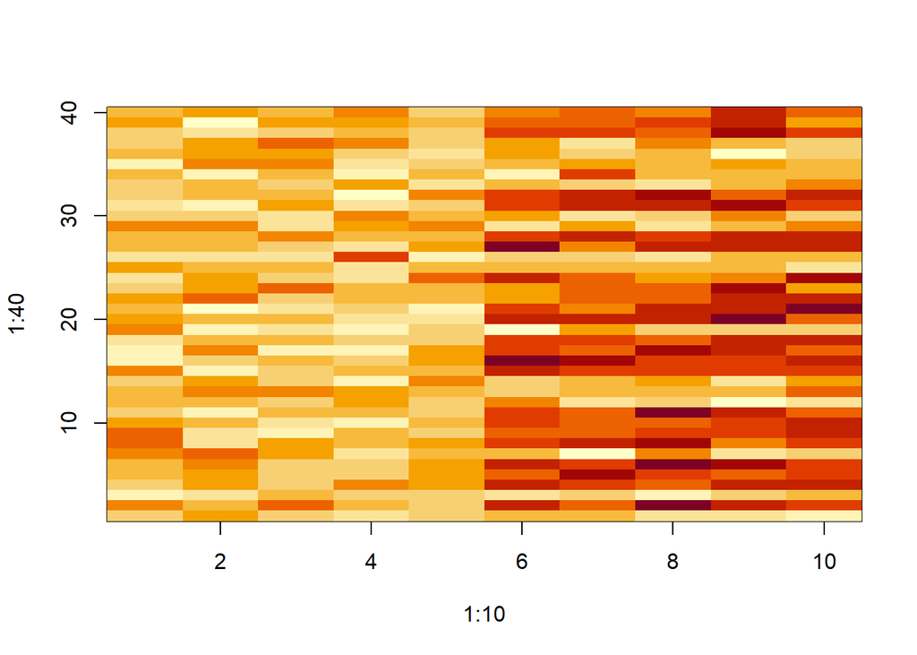

```r
image(1:10,1:40,t(dataMat)[,nrow(dataMat):1])
```

##### Explanation:

- Here’s the image of the altered dataMat after the pattern has been added.
- The pattern is clearly visible in the columns of the matrix.
- The right half is reddish or hotter, indicating higher values in the matrix.

#### 2.2.2 heatmap with Pattern Added

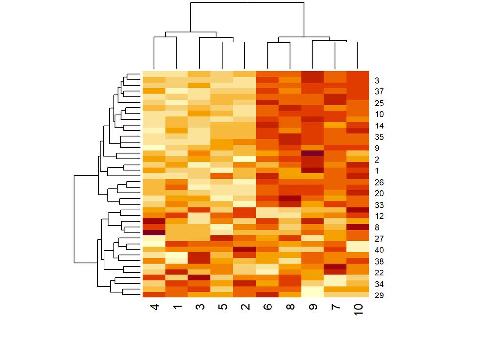

```r
heatmap(dataMat)
```

##### Explanation:

- Again we see the pattern in the columns of the matrix.
- As shown in the dendrogram at the top of the display, these split into 2 clusters,
  - the lower numbered columns (1 through 5) and
  - the higher numbered ones (6 through 10)
- The rows still look random.

#### 2.2.3 Reorder Data according to Clustering to Make Pattern visible

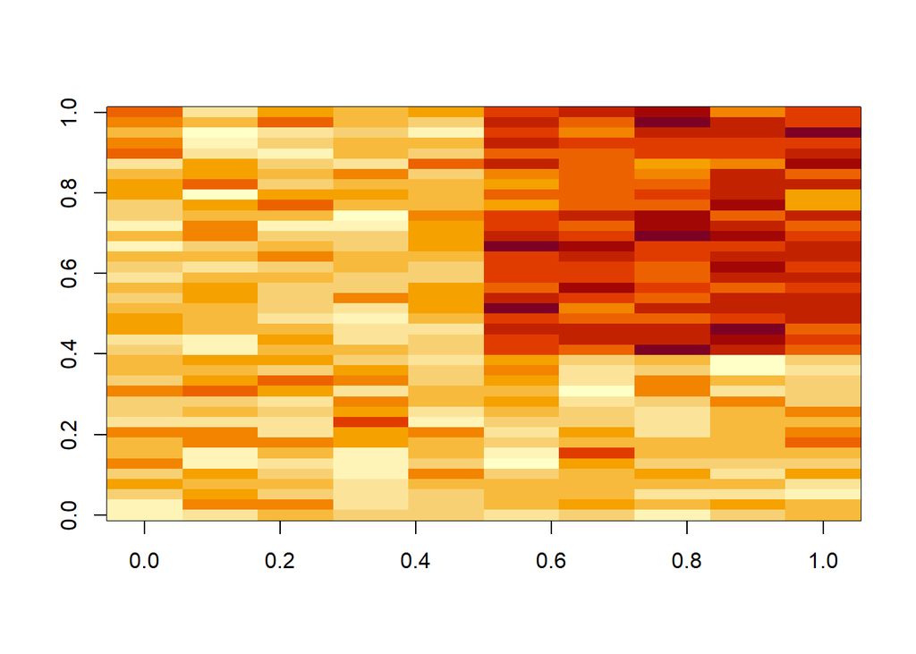

```r
hh <- hclust(dist(dataMat))
dataMatOrdered <- dataMat[hh$order,]

image(t(dataMatOrdered)[,nrow(dataMatOrdered):1])
```

### 2.3 Relationship between PCA and SVD

```r
svd1 <- svd(scale(dataMat)) # dataMatOrdered
svd1
```

```
## $d
##  [1] 12.458121  7.779798  6.732595  6.301878  5.860013  4.501826  3.921267
##  [8]  2.973909  2.401470  2.152848
##
## $u
##              [,1]         [,2]         [,3]          [,4]         [,5]
##  [1,] -0.01126703 -0.127128916 -0.127333286 -0.0859243684 -0.196392022
##  [2,] -0.07287826 -0.227334699 -0.047848612 -0.0200375229  0.140444025
##  [3,] -0.12021471 -0.137239914  0.069911268  0.1195663566 -0.040766731
##  [4,]  0.18307788 -0.097518635 -0.389455810  0.0009410456 -0.032870003
##  [5,]  0.21500524 -0.023391506 -0.080900105 -0.0660488485  0.124988397
##  [6,]  0.14362847  0.145059852 -0.269018604  0.2579859750  0.090595906
##  [7,]  0.11361322  0.089197916  0.146216019  0.0402006348  0.404328837
##  [8,]  0.17174938 -0.159337178  0.020035926  0.0982853744 -0.188457198
##  [9,] -0.16970155  0.302289844 -0.009561794  0.0298244876  0.125536038
```

[output cut: 96 more lines]

```r
pca1 <- prcomp(scale(dataMat))
pca1
```

```
## Standard deviations (1, .., p=10):
##  [1] 1.9948959 1.2457647 1.0780780 1.0091081 0.9383530 0.7208691 0.6279052
##  [8] 0.4762065 0.3845430 0.3447315
##
## Rotation (n x k) = (10 x 10):
##               PC1         PC2         PC3         PC4        PC5          PC6
##  [1,] -0.01269600 -0.17735388  0.24463274 -0.91004953  0.1872010 -0.008213019
##  [2,]  0.11959541  0.48797855 -0.34600069 -0.27630307 -0.5166116 -0.426097876
##  [3,]  0.03336723 -0.01498233 -0.83325514 -0.10279613  0.3916654  0.202164641
##  [4,]  0.09405542 -0.52706147 -0.20958117 -0.13573720 -0.6295808  0.457199442
##  [5,] -0.12201820  0.65260072  0.10178071 -0.14269264 -0.1099219  0.641254633
##  [6,] -0.43175437 -0.03340040 -0.10662102  0.01977183 -0.1601515 -0.094552382
##  [7,] -0.44120227  0.05458792  0.06283533  0.06024994  0.1160080  0.297932642
##  [8,] -0.43732624 -0.01052127 -0.18790005 -0.18937336  0.1696210 -0.183059088
##  [9,] -0.44207248 -0.14804603 -0.10705233  0.07740214 -0.1113648 -0.051388711
## [10,] -0.43924243 -0.01981965  0.09878099 -0.01546923 -0.2364994 -0.152997807
##               PC7          PC8         PC9        PC10
##  [1,]  0.06456695 -0.024609115 -0.07464230  0.18679254
##  [2,]  0.21673650  0.089149131 -0.20830183 -0.06895739
##  [3,]  0.08613180 -0.259091961  0.04853894  0.15035070
##  [4,] -0.04669870  0.044052013  0.01123676 -0.20337161
##  [5,] -0.17040991  0.053081113  0.25570702  0.08927377
##  [6,] -0.65292409 -0.120799342 -0.43700714  0.36639783
##  [7,]  0.46970212 -0.003486847 -0.62595889 -0.28302631
##  [8,] -0.30154820  0.318224392  0.27506907 -0.63821893
##  [9,]  0.35693677  0.527133486  0.28235733  0.51493770
## [10,]  0.21201954 -0.725133698  0.38076511 -0.03978411
```

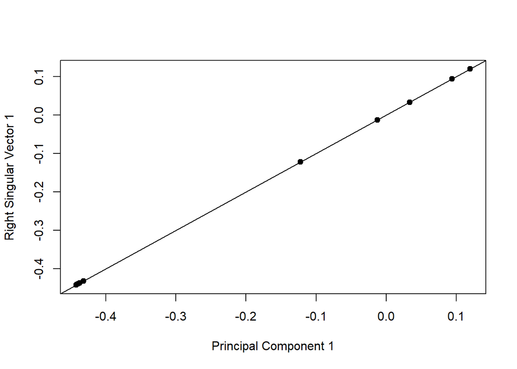

```r
plot(pca1$rotation[,1],svd1$v[,1], pch = 19, xlab = "Principal Component 1", ylab = "Right Singular Vector 1")

abline(lm(svd1$v[,1] ~ pca1$rotation[,1]))
```

##### Explanation:

- Above plot showing the relationship between PCA and SVD for pattern added matrix.
- We’ve plotted 10 points (5 are squished together in the bottom left corner).
  - The x-coordinates are the elements of the first principal component (output from prcomp), and
  - the y-coordinates are the elements of the first column of V, the first right singular vector (gotten from running svd). - We see that the points all lie on the 45 degree line represented by the equation y=x.
- So the first column of V IS the first principal component of our bigger data matrix.

### 2.4 Patterns in Rows and Columns (Without SVD & PCA)

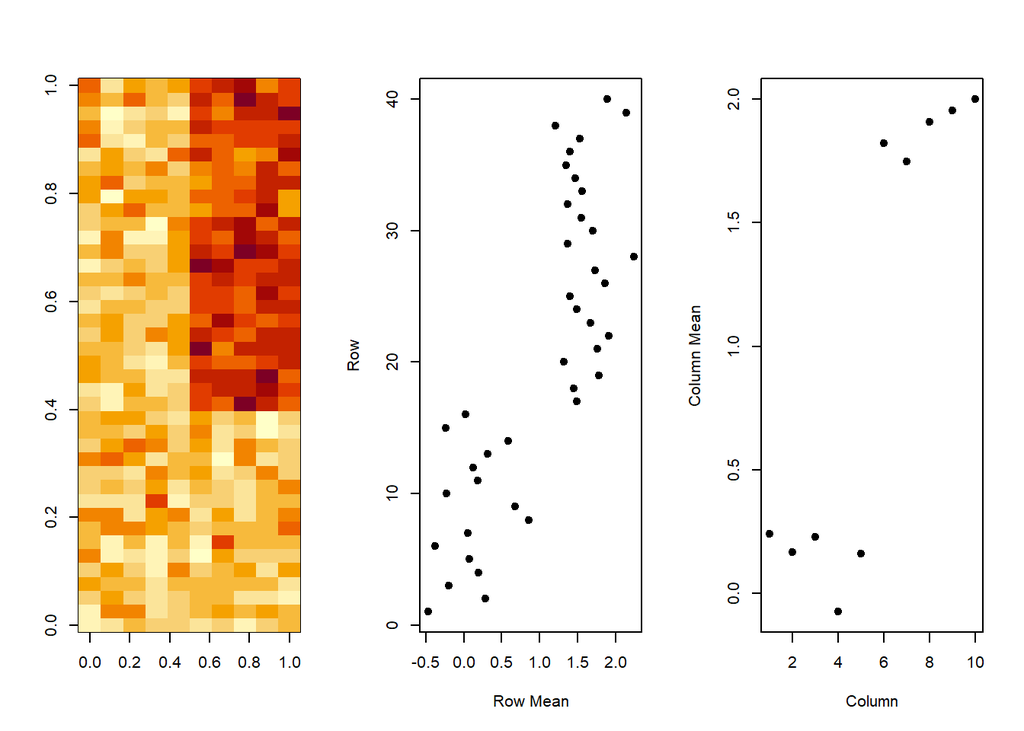

```r
hh <- hclust(dist(dataMat))
dataMatOrdered <- dataMat[hh$order,]

par(mfrow = c(1,3))
image(t(dataMatOrdered)[,nrow(dataMatOrdered):1])

plot(rowMeans(dataMatOrdered),40:1,xlab = "Row Mean", ylab = "Row", pch = 19)


plot(colMeans(dataMatOrdered),xlab = "Column", ylab = "Column Mean", pch = 19)
```

##### Explanation 1 (Leftmost Image):

- Now consider this picture. On the left is an image similar to the heatmap of dataMatix we just plotted.
- It is an image plot of the output of hclust(), a hierarchical clustering function applied to dataMatrix.
  - Red indicates “hotter” or higher values than Yellow.
  - This is consistent with the pattern we applied to the data (increasing the values for some of the rightmost columns).

##### Explanation 2 (Middle Plot):

- The middle display shows the mean of each of the 40 rows (along the x-axis).
- The rows are shown in the same order as the rows of the heat matrix on the left.

##### Explanation 3 (Rightmost Plot):

- The rightmost display shows the mean of each of the 10 columns.
- Here the column numbers are along the x-axis and their means along the y.

##### Explanation 4 (Common):

- We see immediately the connection between the red (hotter) portion of the cluster image and the higher row means, both in the upper right portion of the displays.
- Similarly, the higher valued column means are in the right half of that display and lower colummn means are in the left half.

### 2.5 Patterns in Rows and Columns (With SVD - $u$ and $v$)

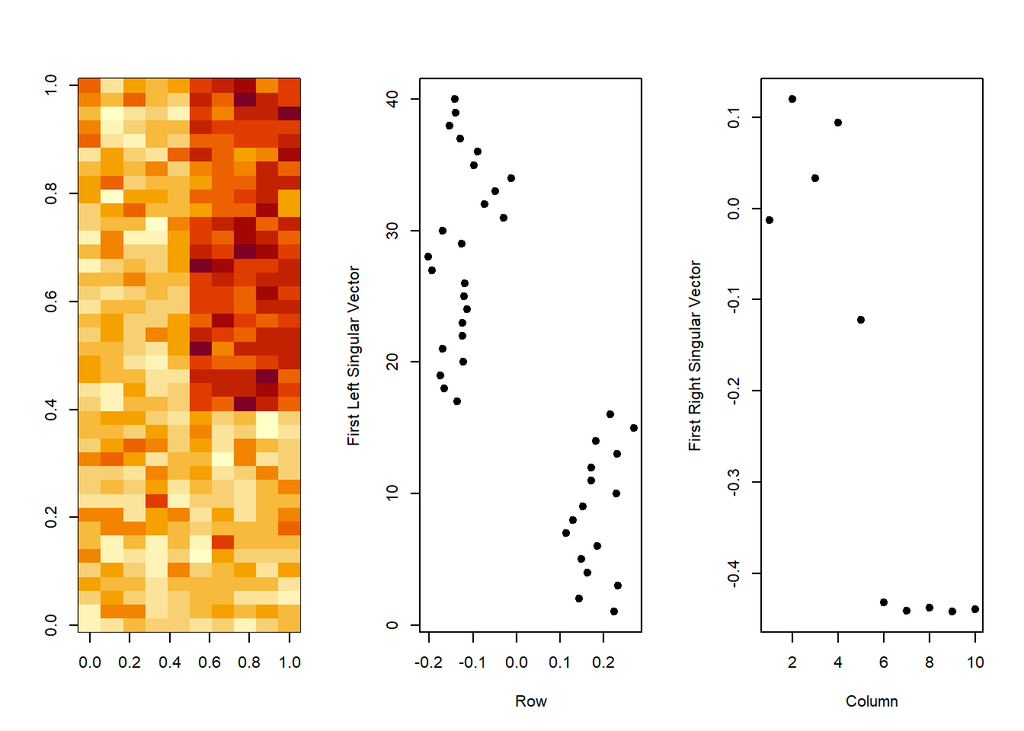

```r
hh <- hclust(dist(dataMat))
dataMatOrdered <- dataMat[hh$order,]

svd2 <- svd(scale(dataMatOrdered))

par(mfrow = c(1,3))
image(t(dataMatOrdered)[,nrow(dataMatOrdered):1])


# Plot for row Without SVD

## plot(rowMeans(dataMatOrdered),40:1,xlab = "Row Mean", ylab = "Row", pch = 19)

# Plot for row  with SVD
plot(svd2$u[,1], 40:1, xlab = "Row", ylab = "First Left Singular Vector", pch = 19)

# Plot for column Without SVD

## plot(colMeans(dataMatOrdered),xlab = "Column", ylab = "Column Mean", pch = 19)

# Plot for column with SVD
plot(svd2$v[,1], xlab = "Column", ylab = "First Right Singular Vector", pch = 19)
```

##### Explanation 1 (Leftmost Image):

- The clustered data matrix on the left.

##### Explanation 2 (Middle Plot):

- Next to it we’ve plotted the first column of the U matrix associated with the scaled data matrix.
- This is the first LEFT singular vector and it’s associated with the ROW means of the clustered data.
- We can see the clear separation between the top 24 (around -0.2) row means and the bottom 16 (around 0.2).
- We don’t show them but note that the other columns of U don’t show this pattern so clearly.

##### Explanation 3 (Rightmost Plot):

- The rightmost display shows the first column of the V matrix associated with the scaled and clustered data matrix.
- This is the first RIGHT singular vector and it’s associated with the COLUMN means of the clustered data.
- You can see the clear separation between the left 5 column means (between -0.1 and 0.1) and the right 5 column means (all below -0.4).
- As with the left singular vectors, the other columns of V don’t show this pattern as clearly as this first one does.

##### Explanation 4 (Common):

- So the singular value decomposition automatically picked up these patterns, the differences in the row and column means.

### 2.5.1 Why were the first columns of both the $U$ and $V$ matrices so special?

- The $D$ matrix of the SVD explains this phenomenon.
- It is an aspect of SVD called **variance explained**.
- As we know that $D$ is the diagonal matrix sandwiched in between $U$ and $V^t$ in the SVD representation of the data matrix.
- The diagonal entries of $D$ are like weights for the $U$ and $V$ columns accounting for the variation in the data.
- They’re given in decreasing order from highest to lowest.

```r
svd2$d
```

```
##  [1] 12.458121  7.779798  6.732595  6.301878  5.860013  4.501826  3.921267
##  [8]  2.973909  2.401470  2.152848
```

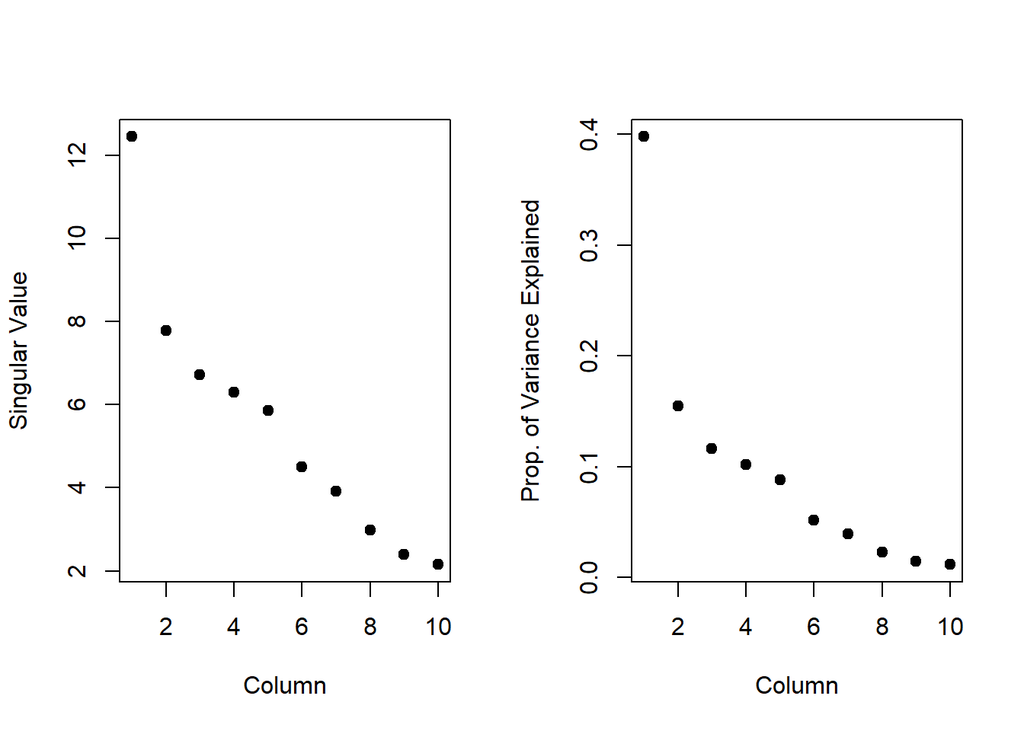

```r
par(mfrow = c(1,2))

plot(svd2$d, xlab = "Column" , ylab = "Singular Value", pch = 19)

plot(svd2$d^2/sum(svd2$d^2), xlab = "Column", ylab = "Prop. of Variance Explained", pch =19)
```

##### Explanation 1 (Left Plot):

- Here’s a display of these values (on the left).
- The first one (12.46) is significantly bigger than the others.

##### Explanation 2 (Right Plot):

- Since we don’t have any units specified, to the right we’ve plotted the proportion of the variance each entry represents.
- We see that the first entry accounts for about 40% of the variance in the data.
- This explains why the first columns of the U and V matrices respectively showed the distinctive patterns in the row and column means so clearly.

### 2.5.2 Example to show how SVD explains Variance

#### 2.5.2.1 Original Matrix

```r
matx2 <- matrix(rep(c(0,1),each = (40*10)/2), nrow = 40)
matx2
```

```
##       [,1] [,2] [,3] [,4] [,5] [,6] [,7] [,8] [,9] [,10]
##  [1,]    0    0    0    0    0    1    1    1    1     1
##  [2,]    0    0    0    0    0    1    1    1    1     1
##  [3,]    0    0    0    0    0    1    1    1    1     1
##  [4,]    0    0    0    0    0    1    1    1    1     1
##  [5,]    0    0    0    0    0    1    1    1    1     1
##  [6,]    0    0    0    0    0    1    1    1    1     1
##  [7,]    0    0    0    0    0    1    1    1    1     1
##  [8,]    0    0    0    0    0    1    1    1    1     1
##  [9,]    0    0    0    0    0    1    1    1    1     1
## [10,]    0    0    0    0    0    1    1    1    1     1
## [11,]    0    0    0    0    0    1    1    1    1     1
## [12,]    0    0    0    0    0    1    1    1    1     1
## [13,]    0    0    0    0    0    1    1    1    1     1
## [14,]    0    0    0    0    0    1    1    1    1     1
```

[output cut: 26 more lines]

##### Explanation:

- You can see that the left 5 columns are all 0’s and the right 5 columns are all 1’s.

#### 2.5.2.2 svd()

```r
svd3 <- svd(matx2)

cat("$d\n",svd3$d,"\n\n")
```

```
## $d
##  14.14214 1.293147e-15 2.515225e-16 8.585184e-31 9.549693e-32 3.330034e-32 2.0226e-46 4.36217e-47 1.531252e-61 0
```

```r
cat("$u - Sample 1 Row\n",svd3$u[1,],"\n\n")
```

```
## $u - Sample 1 Row
##  0.1581139 -0.1897881 0.3728009 0.00649208 0.7536189 0.3722514 0 -0.3033912 0 -0.03740397
```

```r
cat("$v - Sample 1 Row\n",svd3$v[1,])
```

```
## $v - Sample 1 Row
##  0 0 0 0 0 0 0 0 0 1
```

#### 2.5.2.3 SVD - Variance Explained

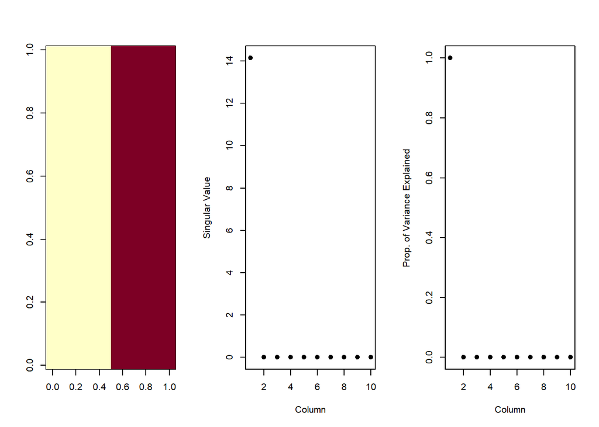

```r
par(mfrow=c(1,3))
image(t(matx2)[,nrow(matx2):1])

plot(svd3$d, xlab = "Column" , ylab = "Singular Value", pch = 19)

plot(svd3$d^2/sum(svd3$d^2), xlab = "Column", ylab = "Prop. of Variance Explained", pch =19)
```

##### Explanation 1 (Left Image):

- Here the picture on the left shows the heat map of matx2.
- You can see how the left columns differ from the right ones.

##### Explanation 2 (Middle Plot):

- The middle plot shows the values of the singular values of the matrix,
  - i.e., the diagonal elements which are the entries of svd3$d.
- Nine of these are 0 and the first is a little above 14.

##### Explanation 3 (Right Plot):

- The third plot shows the proportion of the total each diagonal element represents.
- According to the plot, 100% of the total variation does the first diagonal element account for.
- So what does this mean?
  - Basically that the data is one-dimensional.
  - Only 1 piece of information, namely which column an entry is in, determines its value.

## 3. Case Study: Double Pattern Finding using PCA & SVD

- Now let’s take random 40 by 10 dataMat2
- consider a example in which we add 2 patterns to it.
- we’ll choose which rows to tweak using coinflips.
- Specifically, for each of the 40 rows we’ll flip 2 coins.
  - If the first coinflip is heads, we’ll add 5 to each entry in the right 5 columns of that row, and
  - if the second coinflip is heads, we’ll add 5 to just the even columns of that row.

#### 3.1 Adding 2nd Pattern to Existing Matrix ‘dataMat’

```r
# Adding 2nd Pattern to 'dataMat'
set.seed(678910)

for(i in 1:40) {

  # flip a coin
  coinFlip1 <- rbinom(n = 1, size = 1, prob = 0.5)
  coinFlip2 <- rbinom(n = 1, size = 1, prob = 0.5)

  # if coin is heads add a common pattern to that row

  if(coinFlip1) {
    dataMat[i,] <- dataMat[i,]+rep(c(0,5), each = 5)
  }

  if(coinFlip2) {
    dataMat[i,] <- dataMat[i,]+rep(c(0,5), times = 5)
  }
}
```

#### 3.2 Reorder Data according to Clustering to Make Pattern visible

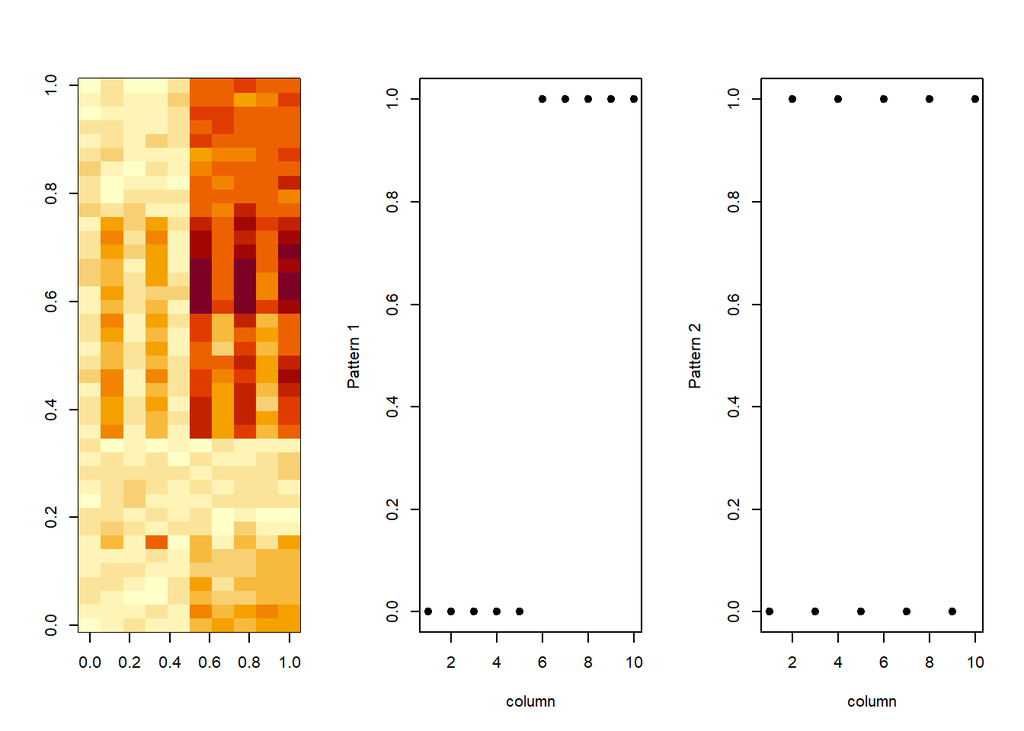

```r
hh <- hclust(dist(dataMat))
dataMatOrdered2 <- dataMat[hh$order,]

par(mfrow = c(1,3))

image(t(dataMatOrdered2)[,nrow(dataMatOrdered2):1])

plot(rep(c(0,1), each = 5), pch = 19, xlab = "column", ylab = "Pattern 1")

plot(rep(c(0,1), times = 5), pch = 19, xlab = "column", ylab = "Pattern 2")
```

##### Explanation 1 (Left Image):

- So here’s the image of the data matrix on the left.
- We can see both patterns, the clear difference between the left 5 and right 5 columns, but also, slightly less visible, the alternating pattern of the columns.

##### Explanation 2 (Middle Plot):

- The middle plot shows the true difference between the left and right columns.

##### Explanation 3 (Right Plot):

- The rightmost plot shows the true difference between the odd numbered and even-numbered columns.

#### 3.3 Can our analysis detect these patterns just from the data?

#### 3.3.1 Examining svd $V^t$ Plot

- Let’s see what SVD shows.
- Since we’re interested in patterns on columns we’ll look at the first two right singular vectors (columns of V) to see if they show any evidence of the patterns.

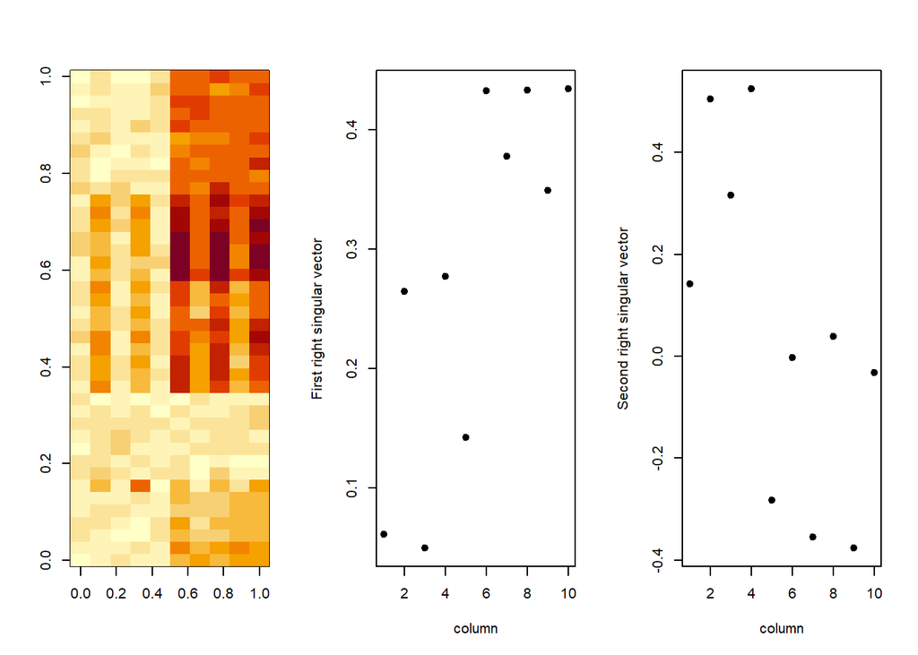

```r
svd4 <- svd(scale(dataMatOrdered2))

par(mfrow = c(1,3))

image(t(dataMatOrdered2)[,nrow(dataMatOrdered2):1])

plot(svd4$v[,1], pch = 19, xlab = "column", ylab = "First right singular vector")

plot(svd4$v[,2], pch = 19, xlab = "column", ylab = "Second right singular vector")
```

##### Explanation 1 (Left Image):

- Image of the data matrix.

##### Explanation 2 (Middle Plot):

- The middle plot does show that the last 5 columns have higher entries than the first 5.
- This picks up, or at least alludes to, the first pattern we added in which affected the last 5 columns of the matrix.

##### Explanation 3 (Right Plot):

- The rightmost plot, showing the second column of V, looks more random.
- However, closer inspection shows that the entries alternate or bounce up and down as you move from left to right.
- This hints at the second pattern we added in which affected only even columns of selected rows.

#### 3.3.2 Examining svd $V^t$ Matrix data

- To see this more closely, look at the first 2 columns of the v component.

```r
svd4$v[,1:2]
```

```
##             [,1]         [,2]
##  [1,] 0.06154540  0.142468636
##  [2,] 0.26433096  0.504510087
##  [3,] 0.04987554  0.316470664
##  [4,] 0.27693897  0.524499356
##  [5,] 0.14275820 -0.282921362
##  [6,] 0.43252652 -0.002280468
##  [7,] 0.37724057 -0.354403893
##  [8,] 0.43280767  0.039226153
##  [9,] 0.34912246 -0.376485206
## [10,] 0.43379723 -0.031422705
```

##### Explanation:

- Seeing the 2 columns side by side, we see that the values in both columns alternately increase and decrease.
- However, we knew to look for this pattern, so chances are, you might not have noticed this pattern if you hadn’t known if was there.
- **This example is meant to show you that it’s hard to see patterns, even straightforward ones.**

#### 3.3.3 Examining svd $D$ Matrix data

```r
svd4$d
```

```
##  [1] 14.084918  8.257842  6.458184  6.100500  5.538262  2.266358  1.955790
##  [8]  1.609508  1.078566  1.054146
```

##### Explanation:

- We see that the first element, 14.08, dominates the others.

#### 3.3.4 Examining svd $D$ Plot

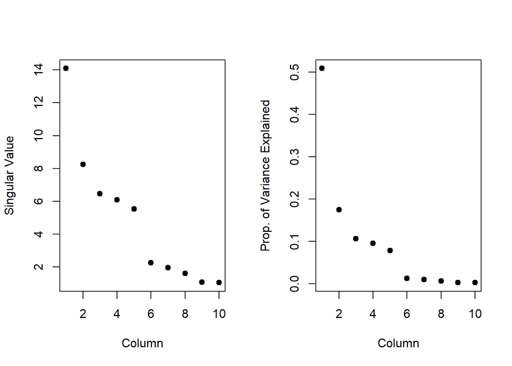

```r
par(mfrow = c(1,2))

plot(svd4$d, xlab = "Column" , ylab = "Singular Value", pch = 19)

plot(svd4$d^2/sum(svd4$d^2), xlab = "Column", ylab = "Prop. of Variance Explained", pch =19)
```

##### Explanation:

- The left shows the numerical entries and
- the right show the percentage of variance each entry explains.
- So the first element which showed the difference between the left and right halves of the matrix accounts for roughly 50% of the variation in the matrix, and
- the second element which picked up the alternating pattern accounts for 18% of the variance.
- The remaining elements account for smaller percentages of the variation.
- This indicates that the first pattern is much stronger than the second.
- Also the two patterns confound each other so they’re harder to separate and see clearly.
- This is what often happens with real data.